# MY474 Summative Assignment #2

WT 2025

## Research Question and Data

🧠 **Research Question**

- Can we predict h01 responses – *“**Should environment or economic growth be prioritized?**”* – from other survey items?

📊 **Data** (BES 2019 cross-sectional)

- h01 (10 point scale) recoded into 3 separate classes:
  - Environment Priority (7–10), Middle (4–6) and Growth Priority (0–3)

🧹 **Preprocessing**

- Dropped variables with >55% missingness
- Recoded structural missing values as a new “Not Applicable” class
- Used SMOTE to balance imbalanced class sizes (~55% Env, 37% Mid, 8% Growth)

🔎 **Why Multi-Class?**

- Binary (env vs. growth) model showed marginally better performance
- But multi-class retained to capture *moderate views* — key for policy nuance

## Modelling Approach & Challenges

- **XGBoost** used for multi-class prediction
  - Handles non-linear patterns & interactions across survey items
- Challenge:
  - Substantial class overlap in PCA space makes preferences hard to distinguish → model fundamentally limited by non-separability
  - Class imbalance compounds difficulty (e.g. Growth group rarely separable)
  - Replication on BES 2017 confirms similar structure and class entanglement

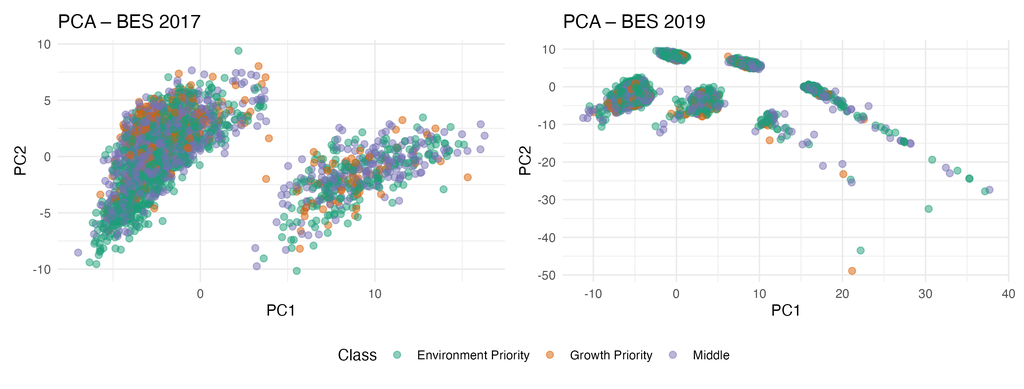

## Results & Interpretations

- Model predicts pro-Environment views reasonably well (Sensitivity ≈ 78%)
- Poor performance on Growth and Middle priorities
  - Growth group rarely identified (~5% sensitivity; precision also low at 38%)
  - Middle group inconsistently predicted (~47% sensitivity)
- Strongest predictors include **Green Party affinity, left–right ideology, ethical consumerism and support for income redistribution**
  - Suggests H01 reflects broader ideological alignment, not just single-issue concern (trend replicated in BES 2017)

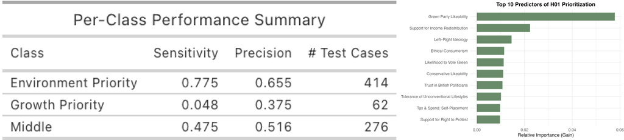

## Conclusions & Implications

1. **Model performance reveals class imbalance challenges**
   - Accurately predicts Environment group (Sensitivity ≈ 78%)
   - Growth class too small (~8%) for stable learning, even after SMOTE
   - Top predictors (e.g. Green Party affinity, left–right ideology) support construct validity of H01
2. **Multi-class model retains important nuance**
   - Binary model simplifies attitudes, but collapses moderates into extremes
   - Middle category captures ambivalent or conflicted views — key for understanding centrist or swing/undecided voters
3. **Recommendation: Retain H01 in future BES surveys**
   - Model cannot reliably recover responses for key subgroups — especially Growth-oriented respondents
   - Dropping H01 risks under-representing respondents with economic or moderate priorities, limiting the survey’s ability to capture the full range of public opinion.